# A) By Number of events by manufacturer

[figure not shown]

[figure not shown]

- wiko.crash : Events for WIKO
- ConfirmPush, RealCall, Cookie and Realinter are java class problems that brought the event.
- mem_less33 : 33% and less of Memory usage during the event
- mem_between : 34% - 65% of Memory usage during the event
- mem_grt66 : 66% and higher of Memory usage during the event
- stor_less33 : 33% and less of Story usage during the event
- stor_between : 34% - 65% of Story usage during the event
- stor_grt66 : 66% and higher of Story usage during the event
- frame1 : LoginContentProvider.java & is frame file problem
- frame2 : ConfirmPushNavFragment.java & is frame file problem
- frame3 : Parcel.java & is frame file problem
- frame4 : PfmData.java & is frame file problem

# 7) *Visualization of Events by manufacturers: Pre-forecastings*

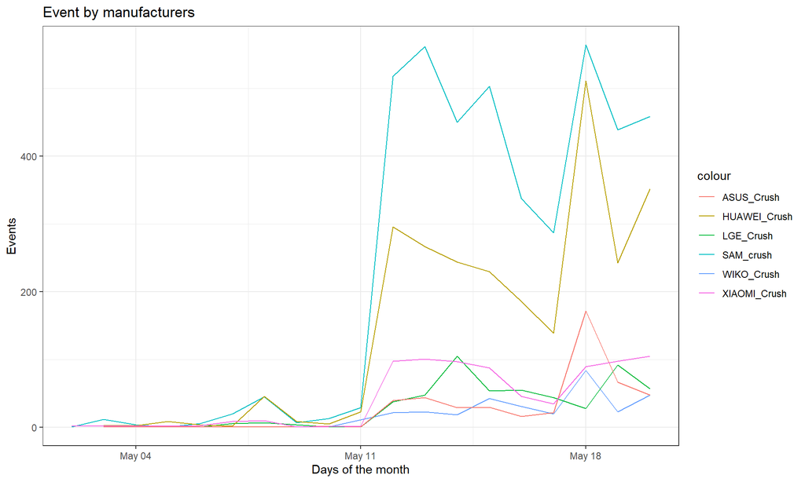

# PART B) predictive modelling

## 1.1) Univariate forecasting: Method One

### a. Forescasting for Samsung: Exponential Smoothing Method and ARIMA

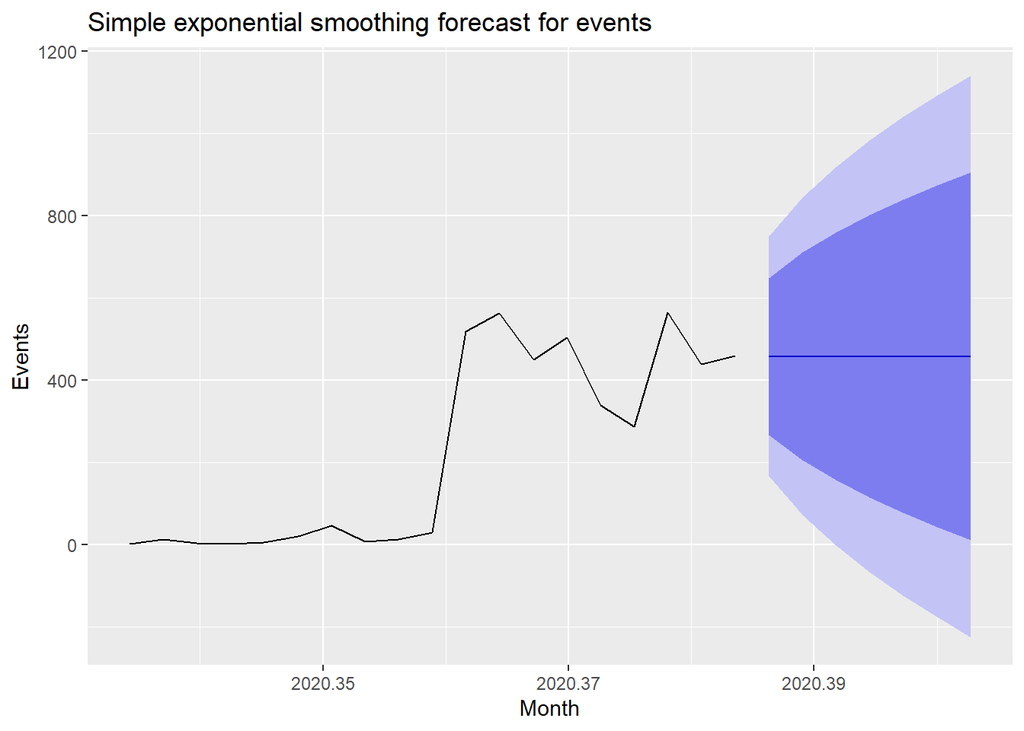

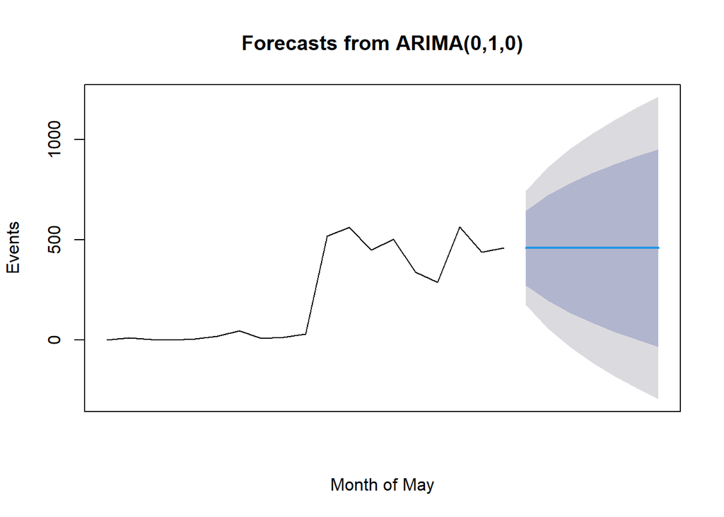

```
## $mean
## Time Series:
## Start = c(2020, 142)
## End = c(2020, 148)
## Frequency = 365
## [1] 459 459 459 459 459 459 459
##
## $lower
## Time Series:
## Start = c(2020, 142)
## End = c(2020, 148)
## Frequency = 365
##                 80%        95%
## 2020.386 272.362694  173.56287
## 2020.389 195.054991   55.33094
## 2020.392 135.734704  -35.39161
## 2020.395  85.725388 -111.87426
## 2020.397  41.666297 -179.25682
## 2020.400   1.833834 -240.17532
## 2020.403 -34.795897 -296.19565
##
## $upper
## Time Series:
## Start = c(2020, 142)
## End = c(2020, 148)
## Frequency = 365
##               80%       95%
## 2020.386 645.6373  744.4371
## 2020.389 722.9450  862.6691
## 2020.392 782.2653  953.3916
## 2020.395 832.2746 1029.8743
## 2020.397 876.3337 1097.2568
## 2020.400 916.1662 1158.1753
## 2020.403 952.7959 1214.1957
```

## b. Forecast for Huwaei: Exp. smoothing & ARIMA

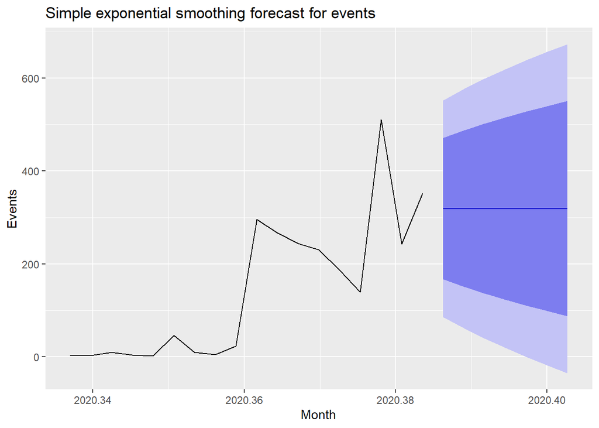

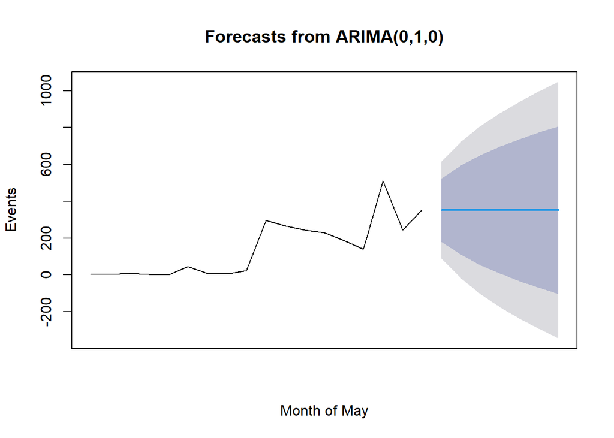

```
## $mean
## Time Series:
## Start = c(2020, 142)
## End = c(2020, 148)
## Frequency = 365
## [1] 352 352 352 352 352 352 352
##
## $lower
## Time Series:
## Start = c(2020, 142)
## End = c(2020, 148)
## Frequency = 365
##                  80%        95%
## 2020.386  180.050858   89.02648
## 2020.389  108.827192  -19.90072
## 2020.392   54.175351 -103.48350
## 2020.395    8.101717 -173.94704
## 2020.397  -32.489969 -236.02666
## 2020.400  -69.187658 -292.15094
## 2020.403 -102.934667 -343.76253
##
## $upper
## Time Series:
## Start = c(2020, 142)
## End = c(2020, 148)
## Frequency = 365
##               80%       95%
## 2020.386 523.9491  614.9735
## 2020.389 595.1728  723.9007
## 2020.392 649.8246  807.4835
## 2020.395 695.8983  877.9470
## 2020.397 736.4900  940.0267
## 2020.400 773.1877  996.1509
## 2020.403 806.9347 1047.7625
```

## c. Forecast for ConfirmPush: Exp. smoothing & ARIMA

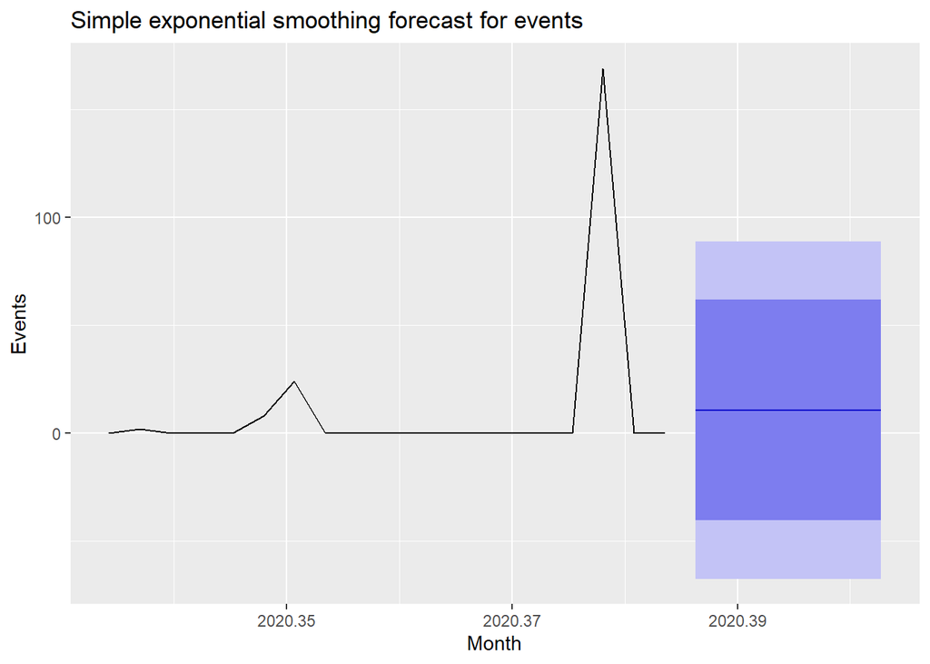

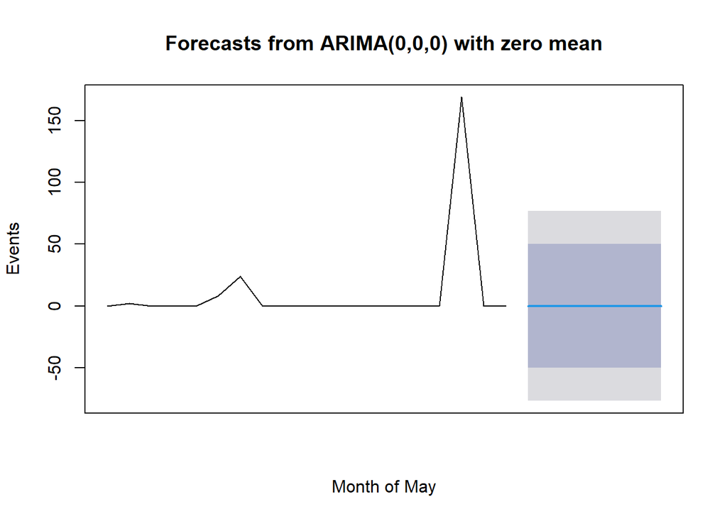

```
## $mean
## Time Series:
## Start = c(2020, 142)
## End = c(2020, 148)
## Frequency = 365
## [1] 0 0 0 0 0 0 0
##
## $lower
## Time Series:
## Start = c(2020, 142)
## End = c(2020, 148)
## Frequency = 365
##                80%       95%
## 2020.386 -50.24443 -76.84222
## 2020.389 -50.24443 -76.84222
## 2020.392 -50.24443 -76.84222
## 2020.395 -50.24443 -76.84222
## 2020.397 -50.24443 -76.84222
## 2020.400 -50.24443 -76.84222
## 2020.403 -50.24443 -76.84222
##
## $upper
## Time Series:
## Start = c(2020, 142)
## End = c(2020, 148)
## Frequency = 365
##               80%      95%
## 2020.386 50.24443 76.84222
## 2020.389 50.24443 76.84222
## 2020.392 50.24443 76.84222
## 2020.395 50.24443 76.84222
## 2020.397 50.24443 76.84222
## 2020.400 50.24443 76.84222
## 2020.403 50.24443 76.84222
```

## d. Forecast for Xiaomi: ARIMA

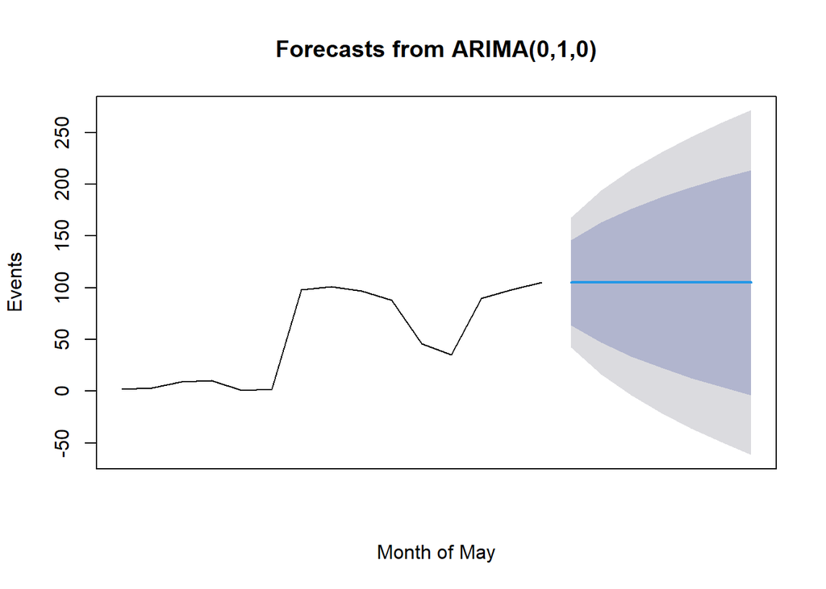

```
## $mean
## Time Series:
## Start = c(2020, 138)
## End = c(2020, 144)
## Frequency = 365
## [1] 105 105 105 105 105 105 105
##
## $lower
## Time Series:
## Start = c(2020, 138)
## End = c(2020, 144)
## Frequency = 365
##                80%       95%
## 2020.375 63.806254  41.99960
## 2020.378 46.743246  15.90398
## 2020.381 33.650339  -4.11989
## 2020.384 22.612508 -21.00080
## 2020.386 12.887984 -35.87317
## 2020.389  4.096342 -49.31883
## 2020.392 -3.988407 -61.68339
##
## $upper
## Time Series:
## Start = c(2020, 138)
## End = c(2020, 144)
## Frequency = 365
##               80%      95%
## 2020.375 146.1937 168.0004
## 2020.378 163.2568 194.0960
## 2020.381 176.3497 214.1199
## 2020.384 187.3875 231.0008
## 2020.386 197.1120 245.8732
## 2020.389 205.9037 259.3188
## 2020.392 213.9884 271.6834
```

## 1.2) Predictive modelling using linear models

- We need a long time-series to do modelling using linear models

```r
#\includepdf[pages=-,nup=2,pagecommand={}]{mychart.pdf}
```